# TS-MT_revisions

# 11 Eclip vs TS by expression

## 11.1 get overlaps of miR-eCLIp with mirTarBase

doing this again because here we can take all transcripts and not just the ones that only have one MRE

```r
#RNA
RNA$expressionTSvenn <- "Non-target"
RNA$expressionTSvenn[RNA$gene_symbol %in% largetframe$geneName] <- "miR-eCLIP"
RNA$expressionTSvenn[RNA$gene_symbol %in% TS$`Target gene`] <- "TargetScan"
RNA$expressionTSvenn[RNA$gene_symbol %in% largetframe$geneName & RNA$gene_symbol %in% TS$`Target gene`] <- "Overlap"


#RPF
RPF$expressionTSvenn <- "Non-target"
RPF$expressionTSvenn[RPF$gene_symbol %in% largetframe$geneName] <- "miR-eCLIP"
RPF$expressionTSvenn[RPF$gene_symbol %in% TS$`Target gene`] <- "TargetScan"
RPF$expressionTSvenn[RPF$gene_symbol %in% largetframe$geneName & RPF$gene_symbol %in% TS$`Target gene`] <- "Overlap"
```

## 11.2 plot expression levels (base mean) split by overlap

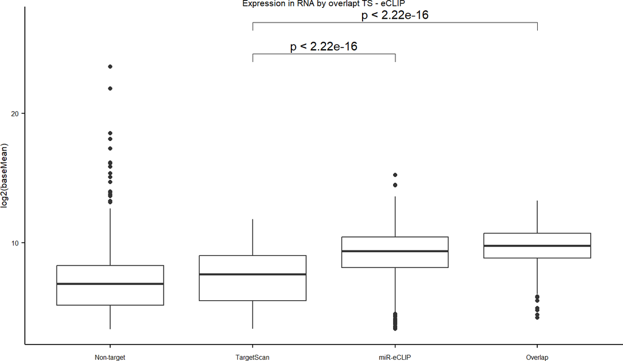

```r
mycomp <- list(c("TargetScan", "miR-eCLIP"), c("TargetScan", "Overlap"))

#RNA
exprplotRNA <- ggplot(RNA, aes(y=log2(baseMean), x=factor(expressionTSvenn, levels = c("Non-target", "TargetScan", "miR-eCLIP", "Overlap") ))) + geom_boxplot() +
  stat_compare_means(comparisons = mycomp) +
  theme_paper() + scale_x_discrete("") +
  ggtitle("Expression in RNA by overlapt TS - eCLIP")
exprplotRNA
```

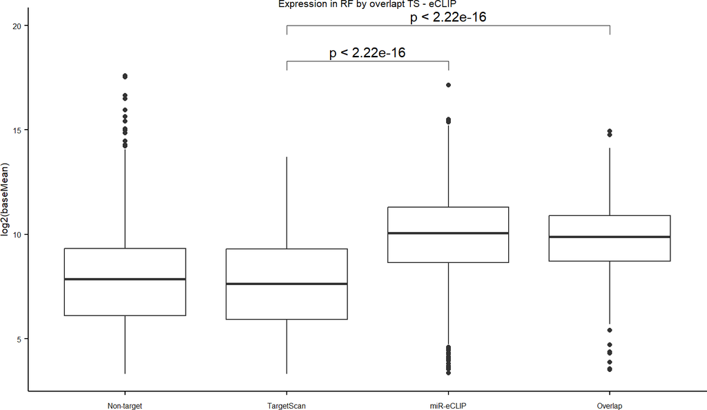

```r
#RPF
exprplotRPF <- ggplot(RPF, aes(y=log2(baseMean), x=factor(expressionTSvenn, levels = c("Non-target", "TargetScan", "miR-eCLIP", "Overlap") ))) + geom_boxplot() +
  stat_compare_means(comparisons = mycomp) +
  theme_paper() + scale_x_discrete("") +
  ggtitle("Expression in RF by overlapt TS - eCLIP")
exprplotRPF
```

```r
#export
pdf("Expression in RNA by overlapt TS_eCLIP.pdf", width = 3, height = 3)
exprplotRNA
dev.off()
```

```r
pdf("Expression in RPF by overlapt TS_eCLIP.pdf", width = 3, height = 3)
exprplotRPF
dev.off()
```

# 12 Eclip vs TS by expression No x cutoff and no non-targets

## 12.1 get overlaps of miR-eCLIp with mirTarBase

doing this again because here we can take all transcripts and not just the ones that only have one MRE

```r
#RNAnolim
RNAnolim$expressionTSvenn <- "Non-target"
RNAnolim$expressionTSvenn[RNAnolim$gene_symbol %in% largetframe$geneName] <- "miR-eCLIP"
RNAnolim$expressionTSvenn[RNAnolim$gene_symbol %in% TS$`Target gene`] <- "TargetScan"
RNAnolim$expressionTSvenn[RNAnolim$gene_symbol %in% largetframe$geneName & RNAnolim$gene_symbol %in% TS$`Target gene`] <- "Overlap"


#RPFnolim
RPFnolim$expressionTSvenn <- "Non-target"
RPFnolim$expressionTSvenn[RPFnolim$gene_symbol %in% largetframe$geneName] <- "miR-eCLIP"
RPFnolim$expressionTSvenn[RPFnolim$gene_symbol %in% TS$`Target gene`] <- "TargetScan"
RPFnolim$expressionTSvenn[RPFnolim$gene_symbol %in% largetframe$geneName & RPFnolim$gene_symbol %in% TS$`Target gene`] <- "Overlap"
```

## 12.2 plot expression levels (base mean) split by overlap

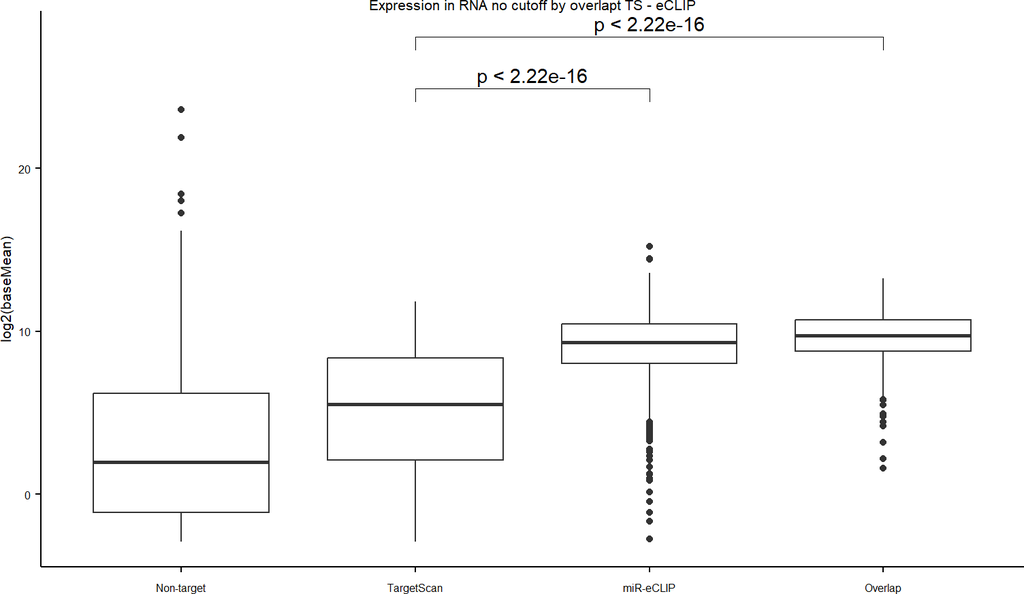

```r
mycomp <- list(c("TargetScan", "miR-eCLIP"), c("TargetScan", "Overlap"))

#RNAnolim
exprplotRNAnolim <- ggplot(RNAnolim, aes(y=log2(baseMean), x=factor(expressionTSvenn, levels = c("Non-target", "TargetScan", "miR-eCLIP", "Overlap") ))) + geom_boxplot() +
  stat_compare_means(comparisons = mycomp) +
  theme_paper() + scale_x_discrete("") +
  ggtitle("Expression in RNA no cutoff by overlapt TS - eCLIP")
exprplotRNAnolim
```

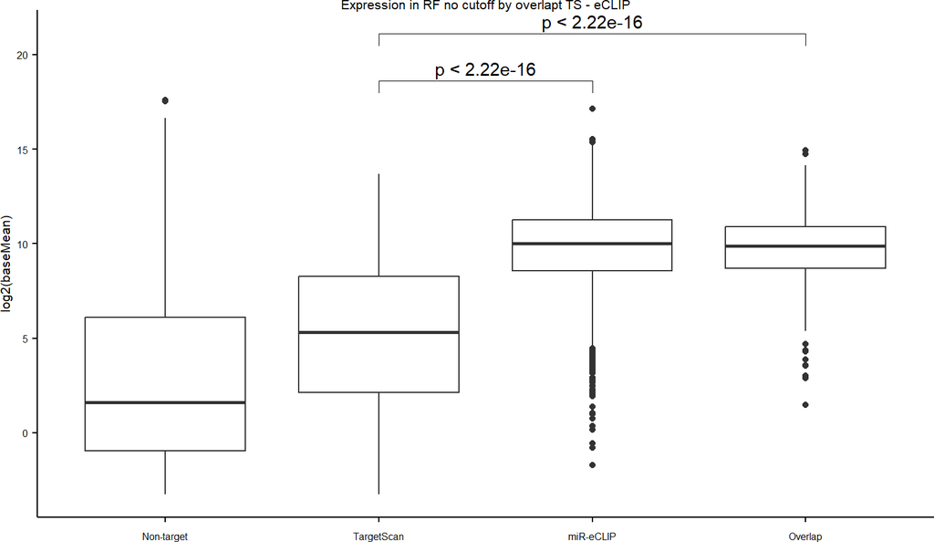

```r
#RPFnolim
exprplotRPFnolim <- ggplot(RPFnolim, aes(y=log2(baseMean), x=factor(expressionTSvenn, levels = c("Non-target", "TargetScan", "miR-eCLIP", "Overlap") ))) + geom_boxplot() +
  stat_compare_means(comparisons = mycomp) +
  theme_paper() + scale_x_discrete("") +
  ggtitle("Expression in RF no cutoff by overlapt TS - eCLIP")
exprplotRPFnolim
```

```r
#export
pdf("Expression in RNAnolim by overlapt TS_eCLIP.pdf", width = 3, height = 3)
exprplotRNAnolim
dev.off()
```

```r
pdf("Expression in RPFnolim by overlapt TS_eCLIP.pdf", width = 3, height = 3)
exprplotRPFnolim
dev.off()
```

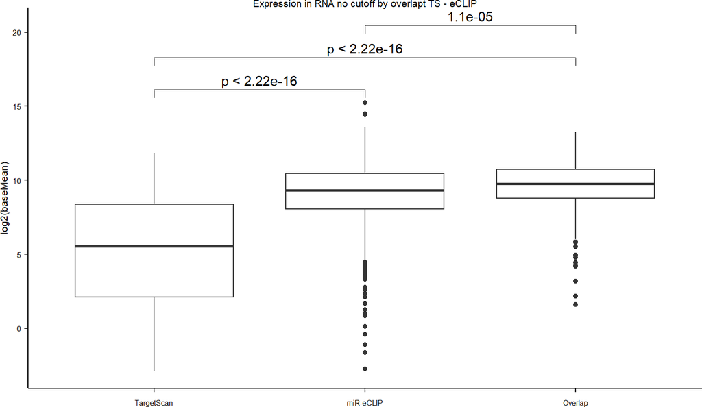

```r
#also remove non targets
mycomp2 <- list(c("TargetScan", "miR-eCLIP"), c("TargetScan", "Overlap"), c("miR-eCLIP", "Overlap"))

#RNAnolim
exprplotRNAnolimnnt <- ggplot(RNAnolim[!(RNAnolim$expressionTSvenn == "Non-target"),], aes(y=log2(baseMean), x=factor(expressionTSvenn, levels = c("TargetScan", "miR-eCLIP", "Overlap") ))) + geom_boxplot() +
  stat_compare_means(comparisons = mycomp2) +
  theme_paper() + scale_x_discrete("") +
  ggtitle("Expression in RNA no cutoff by overlapt TS - eCLIP")
exprplotRNAnolimnnt
```

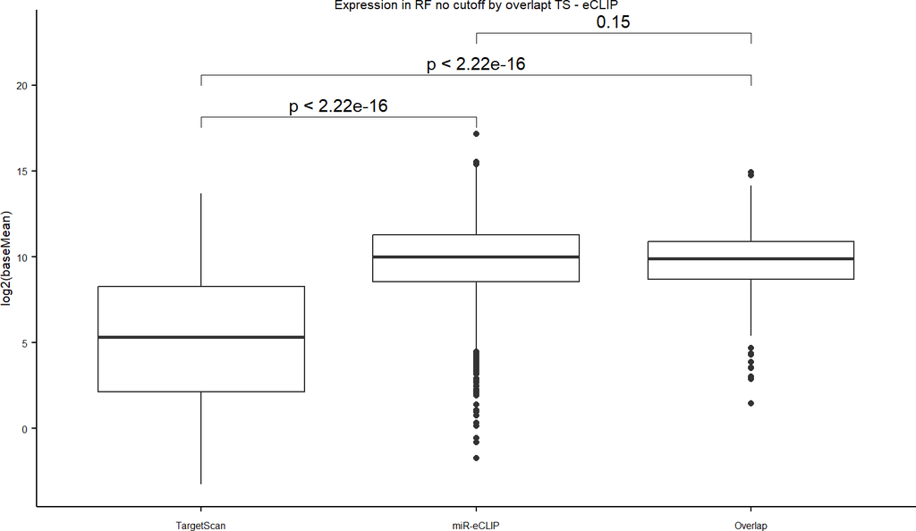

```r
#RPFnolim
exprplotRPFnolimnnt <- ggplot(RPFnolim[!(RPFnolim$expressionTSvenn == "Non-target"),], aes(y=log2(baseMean), x=factor(expressionTSvenn, levels = c("TargetScan", "miR-eCLIP", "Overlap") ))) + geom_boxplot() +
  stat_compare_means(comparisons = mycomp2) +
  theme_paper() + scale_x_discrete("") +
  ggtitle("Expression in RF no cutoff by overlapt TS - eCLIP")
exprplotRPFnolimnnt
```

```r
#export
pdf("Expression in RNAnolim and no nontargets by overlapt TS_eCLIP.pdf", width = 3, height = 3)
exprplotRNAnolimnnt
dev.off()
```

```r
pdf("Expression in RPFnolim and no nontargets by overlapt TS_eCLIP.pdf", width = 3, height = 3)
exprplotRPFnolimnnt
dev.off()
```

# 13 Wobble for only non TS genes

## 13.1 categorize by wobble

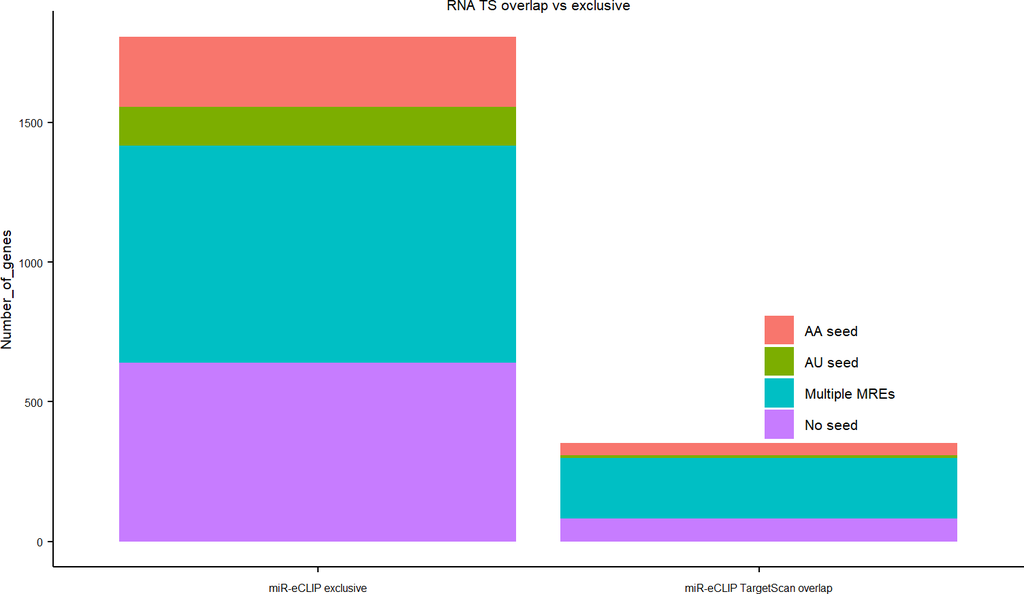

```r
nonts <- largetframe[!(largetframe$geneName %in% TS$`Target gene`),]
olts <- largetframe[largetframe$geneName %in% TS$`Target gene`, ]
#RNA
nontsRNA <- RNA[RNA$gene_symbol %in% nonts$geneName,]
cnontsRNA <- as.data.frame(table(nontsRNA$wobble))
oltsRNA <- RNA[RNA$gene_symbol %in% olts$geneName,]
coltsRNA  <- as.data.frame(table(oltsRNA$wobble))

cnontsRNA$overlap <- "miR-eCLIP exclusive"
coltsRNA$overlap <- "miR-eCLIP TargetScan overlap"
#combine
tsRNA <- rbind(cnontsRNA, coltsRNA)
colnames(tsRNA) <- c("Seed", "Number_of_genes", "Type")


# stacked barchart
tsRNAplot <- ggplot(tsRNA, aes(y=Number_of_genes, x=Type, fill=Seed)) + geom_bar(stat="identity") +
  theme_paper() + scale_x_discrete("") + ggtitle("RNA TS overlap vs exclusive")
tsRNAplot
```

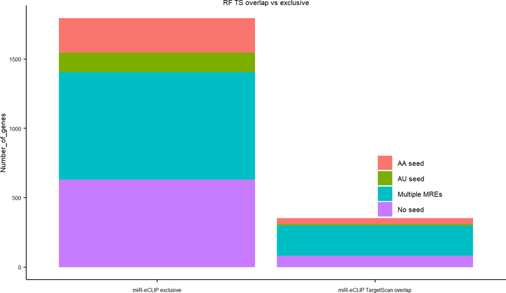

```r
#RPF
nontsRPF <- RPF[RPF$gene_symbol %in% nonts$geneName,]
cnontsRPF <- as.data.frame(table(nontsRPF$wobble))
oltsRPF <- RPF[RPF$gene_symbol %in% olts$geneName,]
coltsRPF  <- as.data.frame(table(oltsRPF$wobble))

cnontsRPF$overlap <- "miR-eCLIP exclusive"
coltsRPF$overlap <- "miR-eCLIP TargetScan overlap"
#combine
tsRPF <- rbind(cnontsRPF, coltsRPF)
colnames(tsRPF) <- c("Seed", "Number_of_genes", "Type")


# stacked barchart
tsRPFplot <- ggplot(tsRPF, aes(y=Number_of_genes, x=Type, fill=Seed)) + geom_bar(stat="identity") +
  theme_paper() + scale_x_discrete("") + ggtitle("RF TS overlap vs exclusive")
tsRPFplot
```

```r
pdf("Barplot_RNA_TS_overlap_vs_exclusive_wobble.pdf", width = 3, height = 3)
tsRNAplot
dev.off()
```

```r
pdf("Barplot_RF_TS_overlap_vs_exclusive_wobble.pdf", width = 3, height = 3)
tsRPFplot
dev.off()
```

## 13.2 repeat without RF or RNA, just eclip data

we are not using this right now but I dont want to delete the code in case we will use it

```r
# nonts$vennpart <- "nonts"
# olts$vennpart <- "olts"
#
# allts <- rbind(nonts, olts)
```

# 14 Region for only non TS genes

## 14.1 categorize by Region

```r
#RNA
RNA$region <- "Non-target"
RNA$region[RNA$gene_symbol %in% largetframe[largetframe$region == "utr5", "geneName"]] <- "utr5"
RNA$region[RNA$gene_symbol %in% largetframe[largetframe$region == "cds", "geneName"]] <- "cds"
RNA$region[RNA$gene_symbol %in% largetframe[largetframe$region == "utr3", "geneName"]] <- "utr3"

table(RNA$region)
```

```
##
##        cds Non-target       utr3       utr5
##        730      11141       1318        112
```

```r
#RPF
RPF$region <- "Non-target"
RPF$region[RPF$gene_symbol %in% largetframe[largetframe$region == "utr5", "geneName"]] <- "utr5"
RPF$region[RPF$gene_symbol %in% largetframe[largetframe$region == "cds", "geneName"]] <- "cds"
RPF$region[RPF$gene_symbol %in% largetframe[largetframe$region == "utr3", "geneName"]] <- "utr3"

table(RPF$region)
```

```
##
##        cds Non-target       utr3       utr5
##        724       9222       1315        108
```

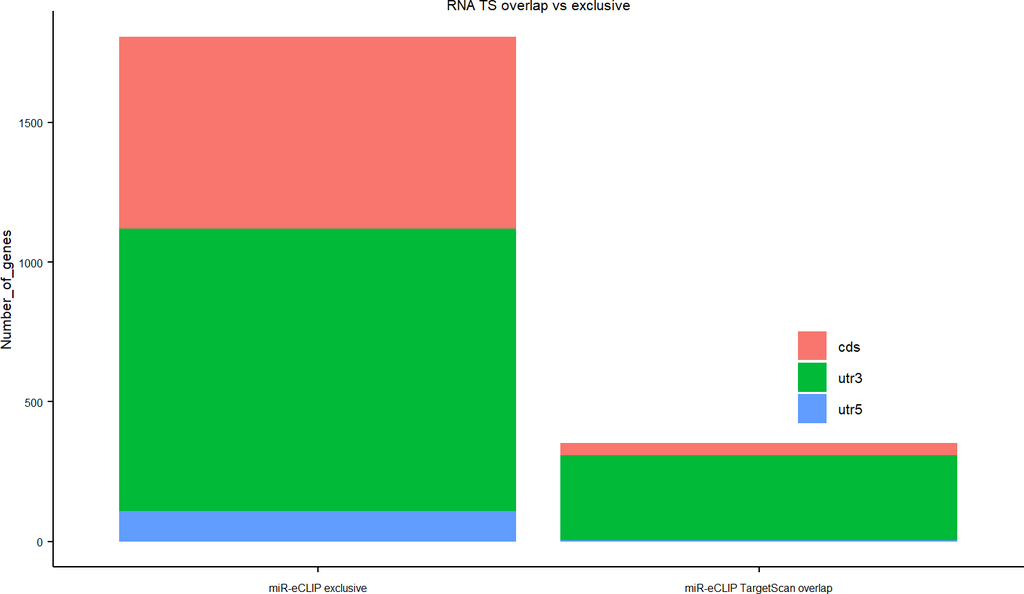

```r
#RNA
nonregtsRNA <- RNA[RNA$gene_symbol %in% nonts$geneName,]
cnontsregRNA <- as.data.frame(table(nonregtsRNA$region))
olregtsRNA <- RNA[RNA$gene_symbol %in% olts$geneName,]
coltsregRNA  <- as.data.frame(table(olregtsRNA$region))

cnontsregRNA$overlap <- "miR-eCLIP exclusive"
coltsregRNA$overlap <- "miR-eCLIP TargetScan overlap"
#combine
tsregRNA <- rbind(cnontsregRNA, coltsregRNA)
colnames(tsregRNA) <- c("Region", "Number_of_genes", "Type")


# stacked barchart
tsregRNAplot <- ggplot(tsregRNA, aes(y=Number_of_genes, x=Type, fill=Region)) + geom_bar(stat="identity") +
  theme_paper() + scale_x_discrete("") + ggtitle("RNA TS overlap vs exclusive")
tsregRNAplot
```

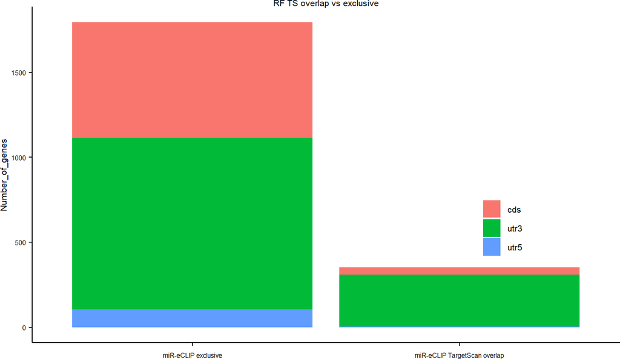

```r
#RPF
nonregtsRPF <- RPF[RPF$gene_symbol %in% nonts$geneName,]
cnontsregRPF <- as.data.frame(table(nonregtsRPF$region))
olregtsRPF <- RPF[RPF$gene_symbol %in% olts$geneName,]
coltsregRPF  <- as.data.frame(table(olregtsRPF$region))

cnontsregRPF$overlap <- "miR-eCLIP exclusive"
coltsregRPF$overlap <- "miR-eCLIP TargetScan overlap"
#combine
tsregRPF <- rbind(cnontsregRPF, coltsregRPF)
colnames(tsregRPF) <- c("Region", "Number_of_genes", "Type")


# stacked barchart
tsregRPFplot <- ggplot(tsregRPF, aes(y=Number_of_genes, x=Type, fill=Region)) + geom_bar(stat="identity") +
  theme_paper() + scale_x_discrete("") + ggtitle("RF TS overlap vs exclusive")
tsregRPFplot
```

```r
pdf("Barplot_RNA_TS_overlap_vs_exclusive_region.pdf", width = 3, height = 3)
tsregRNAplot
dev.off()
```

```r
pdf("Barplot_RF_TS_overlap_vs_exclusive_region.pdf", width = 3, height = 3)
tsregRPFplot
dev.off()
```

# 15 Sattelite repreats overlap miRTarbase

## 15.1 data

```r
#melina repeats
melrep <- readRDS("C:/Users/nikit/Documents/Krueger_Lab/Publications/miR181_paper/Figure4/04_MMsat4/rep_on_transcripts.rds")
MMSAT4 <- melrep[melrep$repName == "MMSAT4"]
MurSatRep1 <- melrep[melrep$repName == "MurSatRep1"]

mmsat4frame <- as.data.frame(MMSAT4)
MurSatRep1frame <- as.data.frame(MurSatRep1)
```

## 15.2 get gene ids

unfortunately the datasets don’t have a matching type of name so we have to get the IDs for miRtarBase using biomart

```r
mart <- useMart("ensembl", dataset = "mmusculus_gene_ensembl", host = "https://jul2019.archive.ensembl.org")
genes <- MTab[!duplicated(MTab$Target), "Target"]
G_list <- getBM(filters= "mgi_symbol", attributes= c("ensembl_gene_id","mgi_symbol"),values=genes,mart= mart)
colnames(G_list) <- c("Gene", "Target")
MTabid <- left_join(MTab,G_list[!duplicated(G_list$Target),],by="Target")
head(MTabid)
```

```
##           ID Species.miRNA. Species.Target.        miRNA Target Reporter.assay
## 1 MIRT752261            mmu             mmu mmu-miR-181a  Ap1g1              0
## 2 MIRT752263            mmu             mmu mmu-miR-181b  Ap1g1              0
## 3 MIRT746725            mmu             mmu mmu-miR-181b   Aqp3              0
## 4 MIRT746726            mmu             mmu mmu-miR-181a   Aqp3              0
## 5 MIRT750537            mmu             mmu mmu-miR-181a Atp2a2              0
## 6 MIRT750538            mmu             mmu mmu-miR-181b Atp2a2              0
##   Western.blot qPCR Microarray NGS pSILAC Other CLIP.Seq Sum Number.of.paper
## 1            0    0          0   0      0     0        1   1               1
## 2            0    0          0   0      0     0        1   1               1
## 3            0    0          0   0      0     0        1   1               2
## 4            0    0          0   0      0     0        1   1               2
## 5            0    0          0   0      0     0        1   1               1
## 6            0    0          0   0      0     0        1   1               1
##   Type               Gene
## 1 weak ENSMUSG00000031731
## 2 weak ENSMUSG00000031731
## 3 weak ENSMUSG00000028435
## 4 weak ENSMUSG00000028435
## 5 weak ENSMUSG00000029467
## 6 weak ENSMUSG00000029467
```

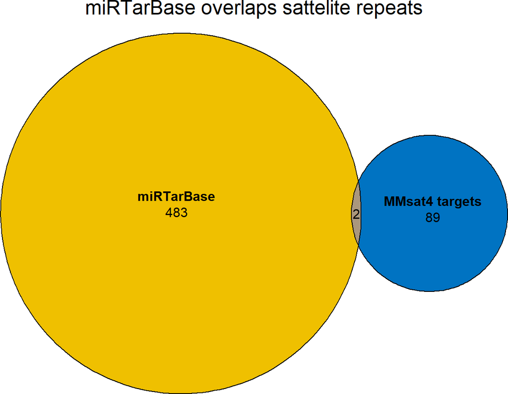

```r
#MMSAT4
vmmsat <- list(MTabid[!duplicated(MTabid$Gene), "Gene"],
               mmsat4frame[!duplicated(mmsat4frame$gene_id) & mmsat4frame$gene_id %in% largetframe$geneID,"gene_id"])
names(vmmsat) <- c("miRTarBase", "MMsat4 targets")

#MurSatRep1
vmur <- list(MTabid[!duplicated(MTabid$Gene), "Gene"],
             MurSatRep1frame[!duplicated(MurSatRep1frame$gene_id) & MurSatRep1frame$gene_id %in% largetframe$geneID,"gene_id"])
names(vmur) <- c("miRTarBase", "MurSatRep1 targets")

#Both
vboth <- list(MTabid[!duplicated(MTabid$Gene), "Gene"],
              mmsat4frame[!duplicated(mmsat4frame$gene_id) & mmsat4frame$gene_id %in% largetframe$geneID,"gene_id"],
              MurSatRep1frame[!duplicated(MurSatRep1frame$gene_id) & MurSatRep1frame$gene_id %in% largetframe$geneID,"gene_id"])
names(vboth) <- c("miRTarBase", "MMsat4 targets", "MurSatRep1 targets")


vmmsatp <- plot(euler(vmmsat, shape = "ellipse"), quantities = T, main="miRTarBase overlaps sattelite repeats", fills=c(farbe2, farbe1))
vmmsatp
```

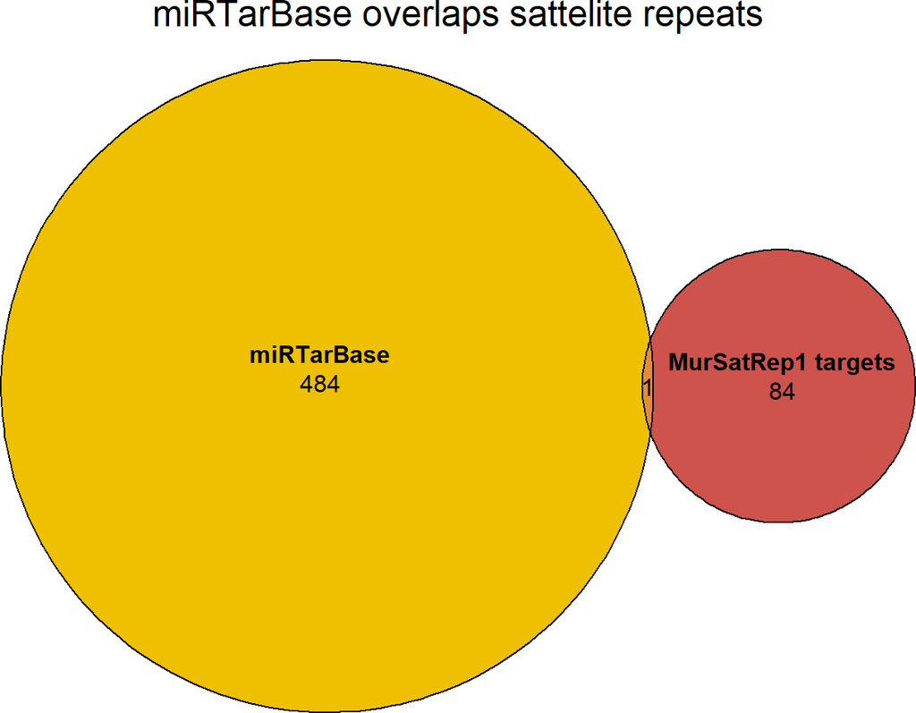

```r
vmurp <- plot(euler(vmur, shape = "ellipse"), quantities = T, main="miRTarBase overlaps sattelite repeats", fills=c(farbe2, farbe3))
vmurp
```

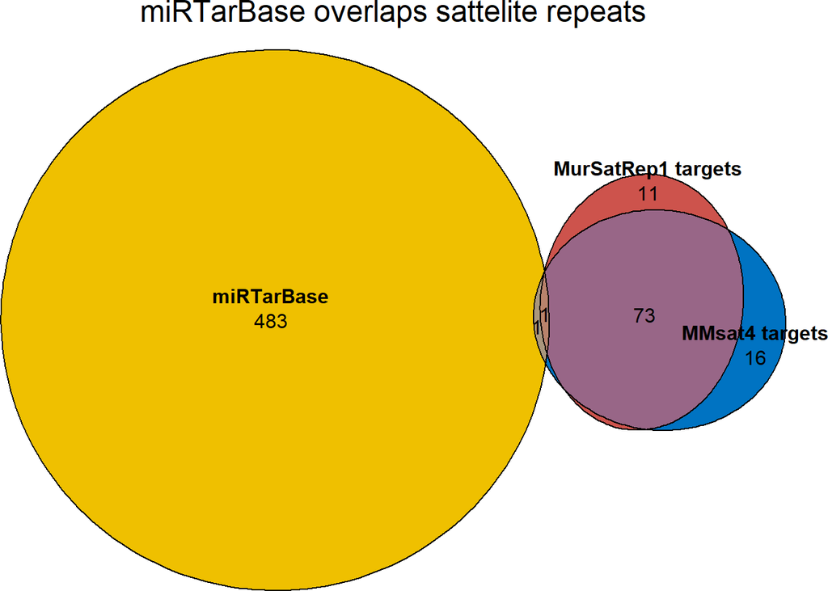

```r
vbothp <- plot(euler(vboth, shape = "ellipse"), quantities = T, main="miRTarBase overlaps sattelite repeats", fills=c(farbe2, farbe1, farbe3))
vbothp
```

```r
pdf("Venn_mmsat4_mirtarbase.pdf", width=4, height = 3)
vmmsatp
dev.off()
```

```r
pdf("Venn_mursatrep1_mirtarbase.pdf", width=4, height = 3)
vmurp
dev.off()
```

```r
pdf("Venn_mmsat4_mursatrep1_mirtarbase.pdf", width=4, height = 3)
vbothp
dev.off()
```